# Global Poverty Trends: A Comprehensive Dataset for Research and Development

Proposal

Project description

Author

Affiliation

InsightArchitect - Ayesha, Shreemithra, Anusha, Eeshaan, Kaarthik, Amaan

School of Information, University of Arizona

## Introduction

In the global mission to tackle poverty, having thorough and trustworthy data is absolutely essential. Our proposal centers around a dataset sourced from Our World in Data, focusing on global poverty trends. With a vast array of indicators spanning income, education, inequality, and welfare policies, this dataset serves as a crucial resource for researchers and policymakers alike. It enables a deeper understanding of the dynamics of poverty across various regions and time-frames, offering insights into the effectiveness of interventions and the distribution of wealth among different income groups.

## Why we are choosing this dataset?

This dataset offers extensive breadth and depth, providing a wealth of poverty-related metrics and variables. With its vast scope, there are abundant opportunities for analysis and exploration, making it an attractive choice for research and intervention purposes. Understanding poverty dynamics is crucial for informing evidence-based interventions aimed at reducing global poverty and fostering inclusive growth.

## Description of an Idea

Building Interactive Dashboards in R. Creating dashboards in R offers a dynamic way to visualize data, utilizing libraries like Shiny and Plot for interactivity. These dashboards enable users to explore trends and patterns efficiently, integrating advanced analyses for informed decision-making.

## Dataset Description

### Dimension:

This `pip_dataset.csv` dataset contains 4,877 rows and 108 columns.

### Provenance:

The main dataset actually focusing on global poverty and inequality for research and development purpose. The Data source link is attached here:

https://ourworldindata.org/search?q=Poverty

### Code book Insights:

As this dataset has about 108 columns but we will work on few columns, that is why we only provided the important data descriptions. Here is the Code book Insights:

Index

Column

Data Type

Description

country

string

The name of the country to which the row relates.

year

integer

Year is the floor of Survey year (i.e. Survey year always rounded down).

reporting_level

string

The reporting level of the survey. It can be national, urban or rural.

headcount_ratio_international_povline

double

% of population living in households with an income or expenditure per person below the International Poverty Line: $1.90 a day

gini

double

The Gini coefficient measures inequality on a scale between 0 and 1, where higher values indicate greater inequality.

mean

double

The mean level of income or expenditure per day.

palma_ratio

double

The Palma ratio is a measure of inequality: it is the share of total income (or expenditure) of the top 10% divided by the share of the bottom 40%.

s80_s20_ratio

double

The share of total income (or expenditure) of the top 20% divided by the share of the bottom 20%.

## Questions 01: Who is Conquering Extreme Poverty in Various Global Regions Across Time? How does the distribution of wealth differ among various income groups?

### The Significance of the Question

The exploration of wealth distribution across societies facilitates the identification of the extent of inequality and its concentration across various income categories. This understanding is crucial for formulating targeted approaches to address inequality and foster economic equity, ensuring that the advantages of growth are distributed more equitably among the entire population.

### Analysis Plan

#### Plot 01 : Stacked Area Chart to know Poverty Trends:

A stacked area chart is an inventive method that may be used. This kind of graphic can show the `headcount_ratio_international_povline` over time for different areas as components of a whole. The data from each region is layered on top of one another, making it possible to see clearly how each region’s proportion of the world’s total headcount of extreme poverty has changed over time.

**Dependency Columns:**

For Plot 01 the dependent columns are **`country`**, **`year`** and **`headcount_ratio_international_povline`**.

**Visualization Descriptions:**

The cumulative percentage of the world’s population living in extreme poverty would be represented by the y-axis, while time (years) would be represented by the x-axis. To facilitate easy differentiation, each region in the stack would be represented by a distinct color or pattern.With the help of this representation, we will be able to observe not only the general downward trend in extreme poverty over time, but also the contributions of various regions to these changes. For example, a region’s area diminishing over time would be indicative of effective measures to reduce poverty in that region. With the use of the chart, policy measures can be focused and focused on reducing poverty by recognizing both global patterns and regional contributions to these trends.

#### Plot 02 : Ridge Plot for Wealth Distribution Analysis:

A ‘Ridge Plot’ is a great tool to compare the distribution of a continuous variable between groups; in this case, the distribution of wealth as determined by `s80_s20_ratio`, `gini`, and `palma_ratio` among different income groups. “Ridge plots” are just a set of vertically arranged, slightly overlapped density charts for every group. It is simpler to compare the distributions and see trends or outlines with this setup in place.

**Dependency Columns:**

For Plot 02 dependent columns are **`gini`**, **`palma_ratio`** and **`s80_s20_ratio`**

**Visualization Descriptions:**

Each ridge (or line) in the figure would indicate the distribution of one of the inequality metrics.  
Each ridge would be labeled with the income group it represents, and the metric value would be represented by the x-axis. It would be simpler to determine which income groups face the greatest inequality if we could see the distribution and central tendency of inequality metrics within each income group. We may determine whether higher income groups likely to have more or less inequality in comparison to lower income groups by analyzing the shapes and peaks of the ridges. A higher peak in the ridge for the top 20% of incomes than for the lowest 20%, for instance, would point to a larger concentration of wealth among the highest earners. The ridge plot can be used to guide policy toward more equitable economic distribution by illuminating the distribution of wealth and assisting in the understanding of not just the degree of inequality within each income group but also how these levels compare across groups.

## Question 02: How do welfare regimes and economic growth rates influence income inequality and poverty dynamics across different countries and continents over the last three decades, influenced by varying welfare types and international poverty lines, and what implications do these interactions have for future global poverty reduction strategies?

### The Significance of the Question:

Welfare Regimes and Economic Growth: This question focuses on the impact of different welfare types and economic growth on income inequality and poverty. It explores how these factors interact within different national and regional contexts.

Geographical and Temporal Scales: The question retains its emphasis on exploring changes across different countries and continents over the past thirty years, providing a long-term perspective on trends and patterns.

Influence of Welfare Types and International Poverty Lines: By including welfare types and considering the role of international poverty lines (as standards for measuring poverty), this question aims to examine how different thresholds and welfare systems impact poverty measurements and perceptions.

Implications for Poverty Reduction: It seeks to understand the effectiveness of various welfare and economic strategies in reducing poverty, aiming to inform future policy decisions.

### Dependency Columns:

These columns include country, year: These attributes are foundational for any analysis that involves temporal and geographical comparisons. welfare_type: Differentiates the types of welfare systems, which can have varying impacts on economic well-being and inequality. ppp_version: Ensures that income and poverty metrics are comparable across different economic conditions globally. Gini index, Palma ratio, S80/S20 ratio, P90/P10 ratio, P90/P50 ratio, P50/P10 ratio: These are critical for analyzing the extent and changes in income inequality.

### Analysis Plan:

The proposed analysis setup provides a comprehensive framework for exploring the complex interplay between poverty, inequality, and economic dynamics at both global and temporal scales. By leveraging interactive visualizations and advanced data querying capabilities, users can gain deep insights into the factors driving poverty and inequality trends, as well as assess the effectiveness of different welfare policies and international poverty interventions.

For the Visualization part of the analysis, the plan includes:

A dynamic 3D globe that visually represents poverty, inequality, and economic indicators across countries and over time, providing a global perspective on the data.

Visualization for Interpretation and Presentation:

Geographical Visualization: Use tools like Globe4r or rl package to create interactive maps that highlight income inequality and welfare types by location.

Interactive Dashboards: Develop a Shiny app or use similar tools to create interactive visualizations that allow users to explore different dimensions of the data, such as toggling between different welfare regimes or time periods.

Dynamic Time-Series Visualizations: Implement line graphs that evolve over time to show trends in inequality indices for different countries or continents.

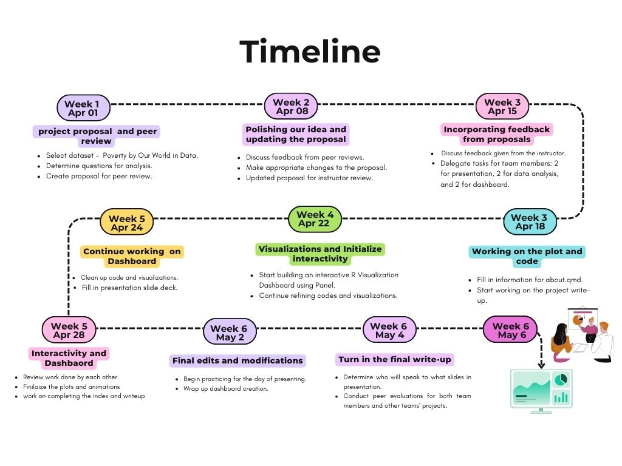

## References

[1] Data source link: https://ourworldindata.org/search?q=Poverty

[2] Github Link: https://github.com/owid/poverty-data/tree/main/datasets